# Exploratory Analysis

## The Dairy Dilemma: Exploring Ice Cream’s Environmental Impact

### Authors

Vamika Goel - vamikag@uw.edu

Hannah Kim - hkim08@uw.edu

Menglu Zhang- menglz2@uw.edu

Rizkika Ramadhanti - kika3431@uw.edu

### Date

Spring 2024

### Abstract

Our main question concerns the popularity of traditional dairy ice cream vs dairy-free ice cream. This question is important due to the substantial greenhouse gas emissions associated with dairy production. To address this issue, we will evaluate customer satisfaction with several well-known ice cream brands, comparing their traditional dairy products to their dairy-free counterparts.

### Keywords

Ice cream, dairy, non-dairy, customer satisfaction, carbon footprint

### Introduction

The project aims to investigate the environmental impact of dairy ice cream consumption using a comprehensive dataset containing flavors, reviews, and other details from popular brands such as Ben & Jerry’s, Häagen-Dazs, Breyers, and Talenti. Three primary research questions guide this inquiry:

Are there significant differences in consumer satisfaction (ratings) between dairy and dairy-free ice creams from the same brand?

What is the impact of introducing dairy-free alternatives on a brand’s overall portfolio performance?

Does a larger assortment of dairy products within a brand correlate with higher or lower average ratings for those products?

These research questions are motivated by the urgent need to address climate change and the significant role that food production, including dairy farming, plays in greenhouse gas emissions. By quantifying the carbon footprint of dairy ice cream production and understanding consumer perceptions, this project seeks to provide insights into the environmental consequences of dietary choices and inform strategies for reducing emissions in the food sector. Moreover, exploring the potential of non-dairy alternatives aligns with broader efforts to promote sustainable consumption patterns and mitigate the impacts of climate change on a global scale.

### Related Work

One of the main concerns with dairy ice cream is its impact on climate change. Many factors go into making the classic dessert that we know today. However, the harm outweighs the good and we want to showcase why trying the dairy-free alternative dessert can make a difference. One of the ingredients that make ice cream its texture is palm oil. Many rainforests in Indonesia and Malaysia are being destroyed for palm oil plantations. Not only will this affect climate change, but it can also threaten the endangered species that live there (WWF, 2016). Not only that, dairy ice cream requires more resources to produce like water, land, and emits more greenhouse gasses into the atmosphere (Ashli, 2023). On the other hand, we’ve come a long way in terms of dairy-free ice cream flavors and they taste just as delicious. There are also many benefits to indulging in dairy-free alternative ice cream. For example, plant-based ice creams made of cashews, almonds, or coconut milk contain more nutrients, vitamins, and minerals for our body. It can also help with heart health, and weight loss, and even reduce the risk of type 2 diabetes (Kumar, 2022). Another benefit to going dairy-free is that no animals will be harmed or exploited in the process!

Kumar, S. (2022, May 26). Vegan ice cream: Why you should invest in dairy-free flavors?. Nature’s Organic Ice Cream. https://www.naturesorganicicecream.com/news-blog/vegan-ice-cream-why-you-should-invest-in-dairy-free-flavors/

Ice cream’s impact on the Environment | Magazine Articles | WWF. (n.d.). https://www.worldwildlife.org/magazine/issues/summer-2016/articles/ice-cream-s-impact-on-the-environment

Ashli. (2023, October 25). What is dairy-free ice cream?. eclipsefoods.com. https://eclipsefoods.com/blog/what-is-dairy-free-ice-cream/#:~:text=Choosing%20dairy%2Dfree%20ice%20cream,greenhouse%20gases%20into%20our%20atmosphere

### The Dataset

Data Source:

Kaggle - Ice Cream Dataset (https://www.kaggle.com/datasets/tysonpo/ice-cream-dataset)

Data Creators:

The ice cream companies ( Ben & Jerrys, Breyes, Talenti Gelato) provided the data but Tyson Pond combined them.

Data Collection:

The data was collected directly from the brand websites: Ben & Jerry’s, Häagen-Dazs, Breyers, and Talenti

1. https://www.benjerry.com/flavors/ice-cream-pints
2. https://www.haagendazs.us/products
3. https://www.breyers.com/us/en/products.html
4. https://www.talentigelato.com/product-category/talenti-gelato-flavors.

Number of Features:8

Considerations: When working with this data, ethical questions include privacy, bias in representation, transparency, power dynamics in reviews, impact on brands, ownership of data, fair use of reviews, and community impact.

Potential Limitations and Problems with this Data: When working with the ice cream dataset, ethical considerations encompass various aspects including privacy, bias in representation, transparency, power dynamics in reviews, impact on brands, ownership of data, fair use of reviews, and community impact. Ensuring reviewers’ privacy, acknowledging potential biases in data collection, maintaining transparency in methodologies, and considering power differentials between consumers and brands are paramount. Ethical analysis should also weigh the impact of findings on brands and the broader community, while respecting ownership rights and adhering to fair use principles. By addressing these ethical questions thoughtfully, researchers can navigate the dataset responsibly, fostering trust and integrity in their analyses while minimizing potential harm.

### Implications

The implication of our ice cream project can be the strategy of changing in ice cream market, making health policy, and developing new ice cream flavors. Based on changing the ice cream market, companies in each brand are able to get the objective data reflected by customers. These data determine which flavors are most popular. Therefore, the business department and marketing department can change the quantity of ice cream production in each flavor and develop inventory management. Additionally, the new products department can suggest new recipes by examining ingredient list. This will help ice cream company to determine the future ice cream market and analyze customers’ preferences. Moreover, our ice cream project can implicate policymakers by showing some health issue related on ice cream ingrediants. By analyzing customers’ feedback, policymakers can related diabetes and sugar levels by using data visualization. Better health policy will be applied based on our ice-cream project. Finally, comparing brands is significant because each brand company has different strategies. Finding out which company is using the best productive efficiency can optimize the ice cream market.

### Limitations & Challenges

Addressing the impact of dairy ice cream on climate change through data analysis presents several challenges and limitations. Firstly, accurately quantifying the environmental footprint of dairy production requires comprehensive data on factors such as greenhouse gas emissions, water usage, and land use, which may be challenging to obtain with precision. Additionally, the dataset’s focus on flavors and reviews may not directly capture environmental metrics, necessitating supplementary data sources or modeling approaches to estimate carbon footprints or other sustainability indicators. Furthermore, the complexity of supply chains in the dairy industry, including variations in production methods and sourcing practices, adds another layer of difficulty in assessing environmental impacts comprehensively. Ethical considerations, such as ensuring fair representation of dairy producers and considering the potential economic ramifications of findings, also require careful attention. Despite these challenges, leveraging the dataset to explore the climate impact of dairy ice cream can still yield valuable insights, provided that limitations are acknowledged and addressed thoughtfully in the analysis.

### Summary Information

Created by Hannah Kim

Our dataset contains a total of `241` different ice creams. The mean rating across all ice creams is `4.22` with a median rating of `4.4`. The average number of ratings received by the ice creams is `90.02` with a median of `59`. This indicates that while some ice creams have been rated very highly, others have received more moderate scores, leading to a broader distribution of ratings.The total number of ratings provides insight into the popularity and consumer interest in these ice creams. Additionally, the variation between the mean and median ratings suggests the presence of outliars or a potentially skewed distribution. This information is crucial for understanding the overall quality and appeal of the ice creams in the dataset. Although the summary isn’t able to give a detailed analysis of dairy vs non-dairy ice creams, it provides a general overview of the dataset’s characteristics.

### Table

Created by Hannah Kim

Ice Creams Grouped by Brand

[output not shown]

*Note: bj = Ben & Jerry’s, hd = Häagen-Dazs*

### Chart 1

Created by Vamika Goel

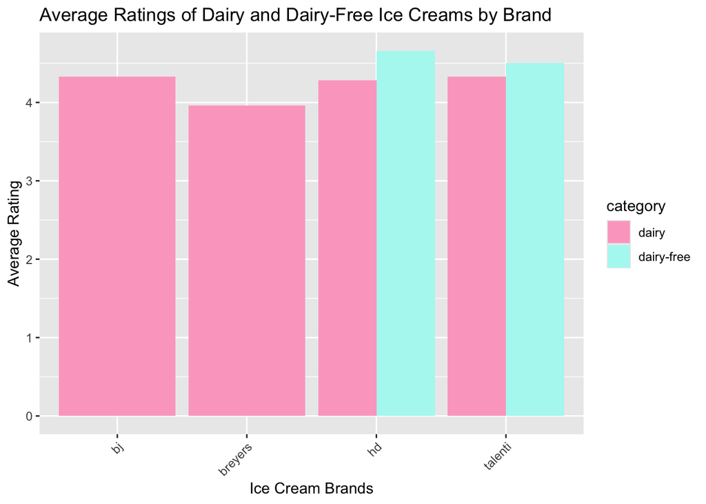

**Purpose:**

The purpose of this analysis is to compare the average ratings of dairy and dairy-free ice creams within each brand. This comparison helps identify which brands are preferred in terms of both dairy and dairy-free products, providing insights into consumer preferences and potentially guiding future product development and marketing strategies.

**Insights:**

Comparison of Dairy and Dairy-Free Products: By comparing the average ratings within each brand, we can see whether dairy or dairy-free ice creams are generally preferred by consumers for each specific brand. Brand Performance: The plot highlights which brands are performing better overall in terms of consumer ratings. Brands with higher average ratings are likely to have better quality or more popular flavors. Consumer Preferences: The comparison can reveal consumer trends, such as a growing preference for dairy-free options if those ratings are higher, which could inform product development and marketing strategies. Identifying Outliers: Brands with a significant difference in ratings between dairy and dairy-free products can be identified, indicating potential areas for improvement in one category.

### Chart 2

Created by Hannah Kim

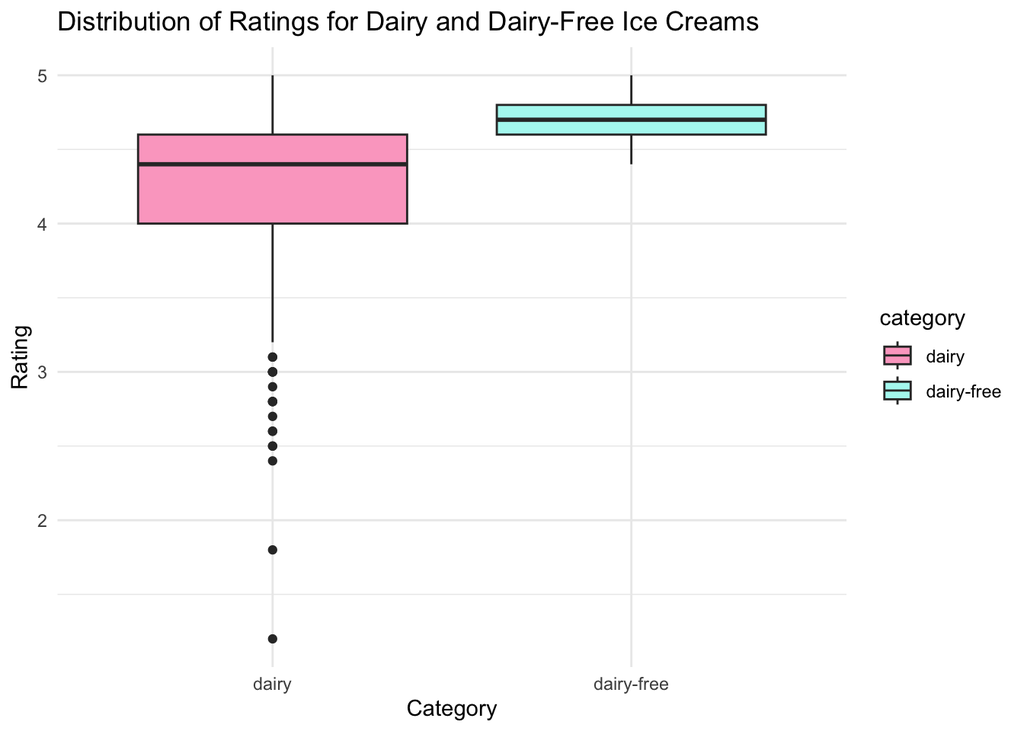

**Purpose:**

A box plot chart was chosen as it effectively provides a visual comparison between the ratings between dairy and dairy-free ice creams. The X-axis represents the dairy and dairy-free categories, while the Y-axis displays the ratings. Each box represents the interquartile range, capturing the middle 50% of the data, with whiskers extending to show the range and outliers.

**Insights:**

The chart suggests that dairy-free ice creams are consistently rated higher and more favorably compare to dairy ice creams. This is shown through the higher median and smaller variability. Dairy ice creams have many outliers as well, which indicate that consumer opinions on dairy ice creams are much more diverse.

### Chart 3

Created by Rizkika Ramadhanti

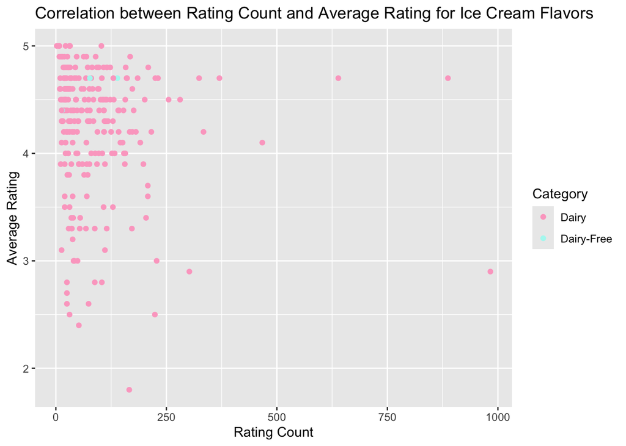

**Purpose:**

The chosen scatter plot effectively illustrates the potential correlation between two critical factors: the popularity and satisfaction level of ice cream flavors. The plot offers a straightforward visual representation by plotting each flavor as a point, with its position determined by both its rating count and average rating. Through this chart, we can quickly discern patterns: whether highly-rated flavors tend to attract more ratings or if there’s no clear relationship between popularity and satisfaction.

**Insights:**

The scatter plot reveals critical insights into the relationship between the popularity and satisfaction levels of ice cream flavors. Flavors positioned in the upper-right quadrant are popular and highly rated, indicating strong market performers ideal for promotional focus. Conversely, flavors in the upper-left quadrant have low popularity despite their high satisfaction ratings, suggesting potential for growth through targeted marketing. Flavors in the lower-right quadrant attract many consumers but receive low satisfaction ratings, highlighting a need for quality improvements. Overall, the distribution of points indicates general consumer trends and helps manufacturers and retailers make strategic decisions in product development, marketing, and inventory management by identifying which flavors resonate most with consumers.